# hw02-MeiqiYu

```r
library(gapminder)
library(tidyverse)
```

# Smell test the data

- Gapminder is a data.frame which is a rectangular collection of variables (in the columns) and observations (in the rows).
- It contains 6 cloumns and 1704 rows.
- We could get the facts about “extent” and “size” in the following six ways.
1. `gapminder` It shows the entire dataframe which contains 6 comlumns and 1704 rows.

```r
gapminder
```

```
## # A tibble: 1,704 x 6
##    country     continent  year lifeExp      pop gdpPercap
##    <fct>       <fct>     <int>   <dbl>    <int>     <dbl>
##  1 Afghanistan Asia       1952    28.8  8425333      779.
##  2 Afghanistan Asia       1957    30.3  9240934      821.
##  3 Afghanistan Asia       1962    32.0 10267083      853.
##  4 Afghanistan Asia       1967    34.0 11537966      836.
##  5 Afghanistan Asia       1972    36.1 13079460      740.
##  6 Afghanistan Asia       1977    38.4 14880372      786.
##  7 Afghanistan Asia       1982    39.9 12881816      978.
##  8 Afghanistan Asia       1987    40.8 13867957      852.
##  9 Afghanistan Asia       1992    41.7 16317921      649.
## 10 Afghanistan Asia       1997    41.8 22227415      635.
## # ... with 1,694 more rows
```

```r
head(gapminder)
```

```
## # A tibble: 6 x 6
##   country     continent  year lifeExp      pop gdpPercap
##   <fct>       <fct>     <int>   <dbl>    <int>     <dbl>
## 1 Afghanistan Asia       1952    28.8  8425333      779.
## 2 Afghanistan Asia       1957    30.3  9240934      821.
## 3 Afghanistan Asia       1962    32.0 10267083      853.
## 4 Afghanistan Asia       1967    34.0 11537966      836.
## 5 Afghanistan Asia       1972    36.1 13079460      740.
## 6 Afghanistan Asia       1977    38.4 14880372      786.
```

3. `str(gapminder)` The result shows apparently the class, number of rows and varibles.

```r
str(gapminder)
```

```
## Classes 'tbl_df', 'tbl' and 'data.frame':    1704 obs. of  6 variables:
##  $ country  : Factor w/ 142 levels "Afghanistan",..: 1 1 1 1 1 1 1 1 1 1 ...
##  $ continent: Factor w/ 5 levels "Africa","Americas",..: 3 3 3 3 3 3 3 3 3 3 ...
##  $ year     : int  1952 1957 1962 1967 1972 1977 1982 1987 1992 1997 ...
##  $ lifeExp  : num  28.8 30.3 32 34 36.1 ...
##  $ pop      : int  8425333 9240934 10267083 11537966 13079460 14880372 12881816 13867957 16317921 22227415 ...
##  $ gdpPercap: num  779 821 853 836 740 ...
```

4. `summary(gapminder)` It is a summary about the dataframe so you can easily find that how many varibles it contains. It will be used to help us get a knowledge about the minimun value, the max value, 1st Qu.,3rd Qu. and median.

```r
summary(gapminder)
```

```
##         country        continent        year         lifeExp
##  Afghanistan:  12   Africa  :624   Min.   :1952   Min.   :23.60
##  Albania    :  12   Americas:300   1st Qu.:1966   1st Qu.:48.20
##  Algeria    :  12   Asia    :396   Median :1980   Median :60.71
##  Angola     :  12   Europe  :360   Mean   :1980   Mean   :59.47
##  Argentina  :  12   Oceania : 24   3rd Qu.:1993   3rd Qu.:70.85
##  Australia  :  12                  Max.   :2007   Max.   :82.60
##  (Other)    :1632
##       pop              gdpPercap
##  Min.   :6.001e+04   Min.   :   241.2
##  1st Qu.:2.794e+06   1st Qu.:  1202.1
##  Median :7.024e+06   Median :  3531.8
##  Mean   :2.960e+07   Mean   :  7215.3
##  3rd Qu.:1.959e+07   3rd Qu.:  9325.5
##  Max.   :1.319e+09   Max.   :113523.1
##
```

5.`dim(gapminder)` `dim()` can be used to obtain the dimensions of the data frame (number of rows and number of columns). The output is a vector.

```r
dim(gapminder)
```

```
## [1] 1704    6
```

6.`nrow()`and`ncol()` These two function can help us get number of rows and number of columns, respectively.

```r
nrow(gapminder)
```

```
## [1] 1704
```

```r
ncol(gapminder)
```

```
## [1] 6
```

# Explore individual variables

In this part, I choose the following two varibles to explore: `continent` and `year`. * Possible range of `continent`: Asia, Europe, Africa Americas and Oceania * Possible values of `year`: 1952 1957 1962 1967 1972 1977 1982 1987 1992 1997 2002 2007.

```r
unique(gapminder$continent)
```

```
## [1] Asia     Europe   Africa   Americas Oceania
## Levels: Africa Americas Asia Europe Oceania
```

```r
unique(gapminder$year)
```

```
##  [1] 1952 1957 1962 1967 1972 1977 1982 1987 1992 1997 2002 2007
```

- Typical values contain the Min., 1st Qu., Median, Mean, 3rd QU., Max. For the `year` varible, the Min= 1952, 1st quartile= 1966, Median= 1980, Mean= 1980, 3rd quartile= 1993, Max= 2007.

```r
summary(gapminder$year)
```

```
##    Min. 1st Qu.  Median    Mean 3rd Qu.    Max.
##    1952    1966    1980    1980    1993    2007
```

- Spread of data

Overall range = max-min Overall range of `year` equals to 55.

- Distribution of data
- The shape of `year` is uniform, which means about the same amount of data occurs for each varible value.
- Mean and Median of `year` both equal to 1980.

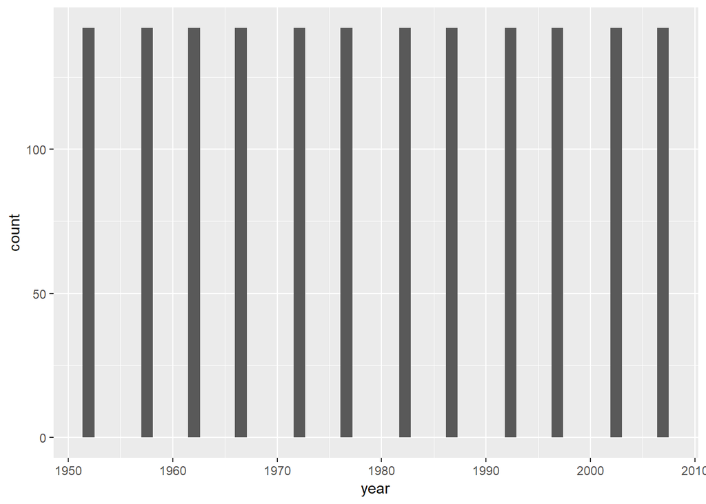

```r
ggplot(gapminder,aes(year))+
  geom_histogram(bins=50)
```

- The standard deviation of an observation variable is the square root of its variance. We can know the standard deviation of `year` equals to 17.26533 from the below.

```r
sd(gapminder$year)
```

```
## [1] 17.26533
```

# Explore various plot types

- A scatterplot of lifeExp and gdpPercap in blue.

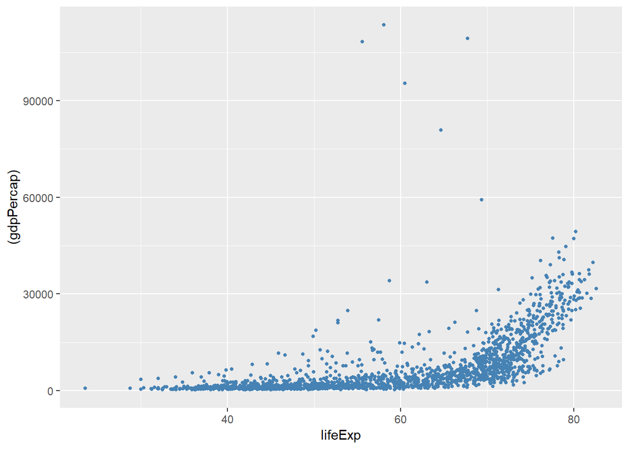

```r
ggplot(gapminder,aes(x=lifeExp, y=(gdpPercap)))+
  geom_point(color='steelblue',size=1)
```

- A histogram of lifeExp with bins = 100.

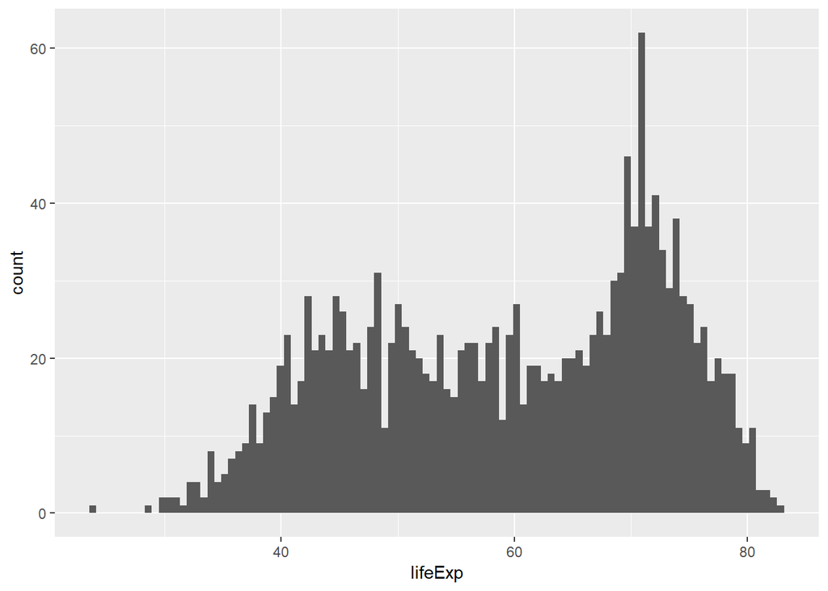

```r
ggplot(gapminder,aes(lifeExp))+
  geom_histogram(bins=100)
```

- A densityplot of lifeExp.

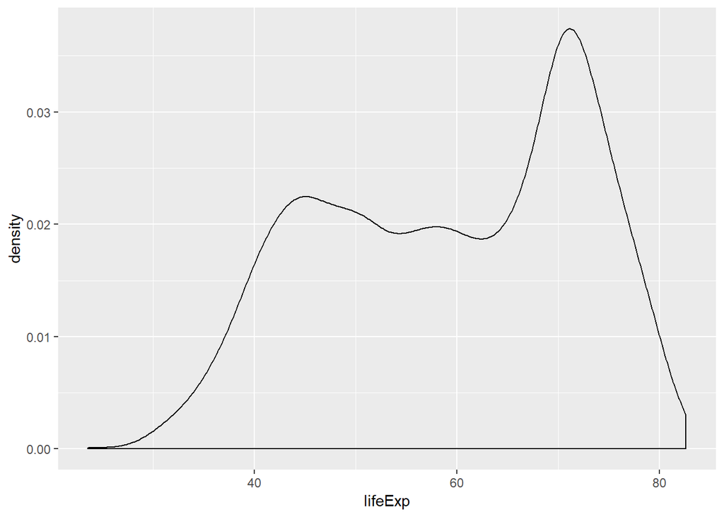

```r
ggplot(gapminder,aes(lifeExp))+
  geom_density(bw=2)
```

*A boxplot for all the continents vs lifeExp.

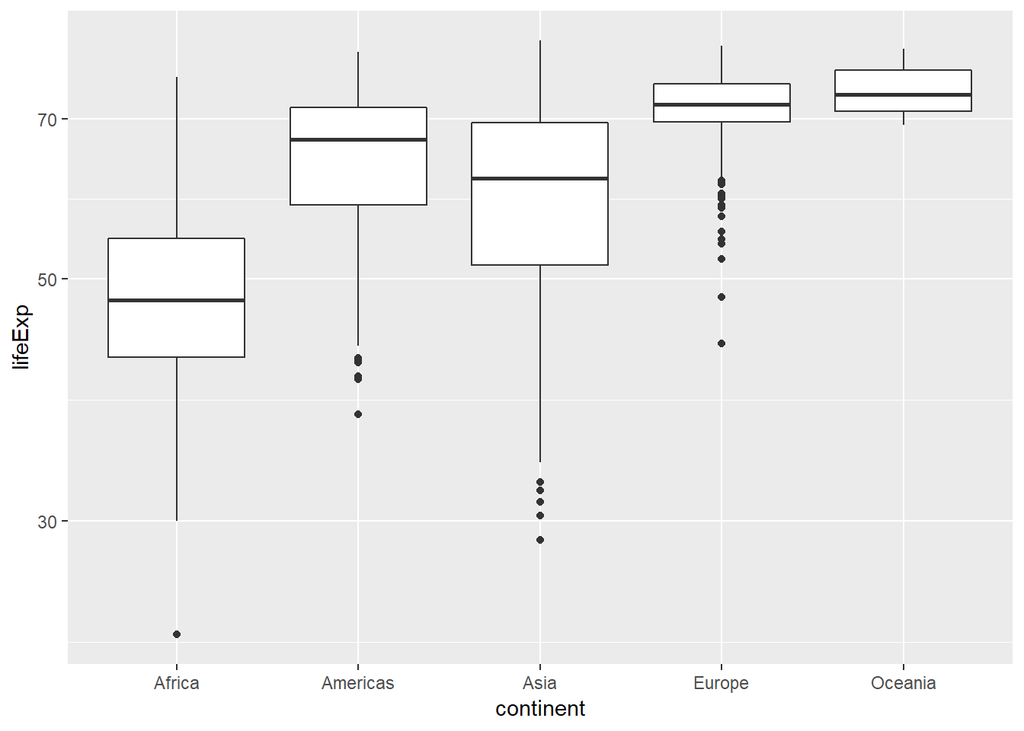

```r
a <- ggplot(gapminder,aes(continent,lifeExp)) +
  scale_y_log10()
a + geom_boxplot()
```

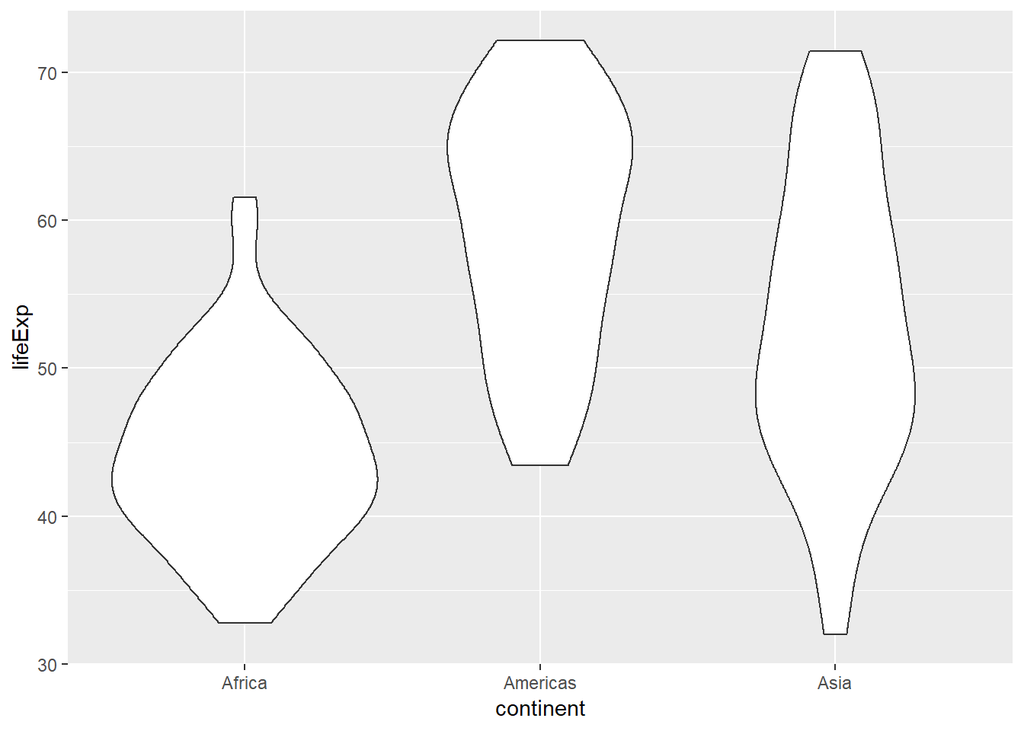

```r
gapminder %>%
  filter((continent == 'Americas' |continent == 'Africa'|continent == 'Asia') & year>=1960 & year < 1970) %>%
  ggplot(aes(continent,lifeExp))+
  geom_violin()
```

# Use filter(), select() and %>%

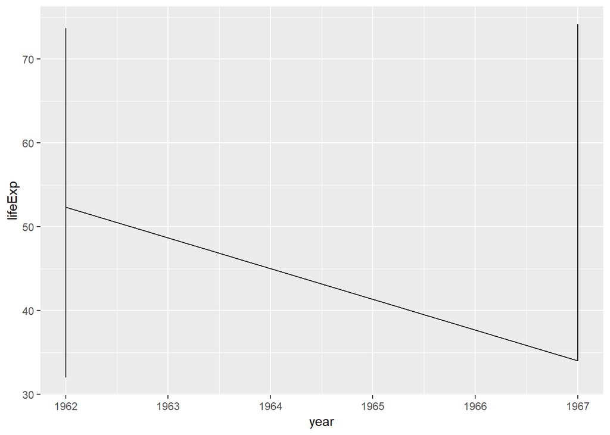

```r
select(gapminder, year,lifeExp) %>%
  filter(year>=1960 & year < 1970) %>%
  ggplot(aes(year,lifeExp))+
  geom_line()
```

# But I want to do more!

By running this code `filter(gapminder, country == c("Rwanda", "Afghanistan"))`, the analyst didn’t secceed to get what they want. They only got part of the result.

```r
filter(gapminder, country == c("Rwanda", "Afghanistan"))
```

```
## # A tibble: 12 x 6
##    country     continent  year lifeExp      pop gdpPercap
##    <fct>       <fct>     <int>   <dbl>    <int>     <dbl>
##  1 Afghanistan Asia       1957    30.3  9240934      821.
##  2 Afghanistan Asia       1967    34.0 11537966      836.
##  3 Afghanistan Asia       1977    38.4 14880372      786.
##  4 Afghanistan Asia       1987    40.8 13867957      852.
##  5 Afghanistan Asia       1997    41.8 22227415      635.
##  6 Afghanistan Asia       2007    43.8 31889923      975.
##  7 Rwanda      Africa     1952    40    2534927      493.
##  8 Rwanda      Africa     1962    43    3051242      597.
##  9 Rwanda      Africa     1972    44.6  3992121      591.
## 10 Rwanda      Africa     1982    46.2  5507565      882.
## 11 Rwanda      Africa     1992    23.6  7290203      737.
## 12 Rwanda      Africa     2002    43.4  7852401      786.
```

The correct way to do this is listed below:

```r
  d <- filter(gapminder,country == 'Rwanda' | country == 'Afghanistan')
  knitr::kable(d)
```

| country | continent | year | lifeExp | pop | gdpPercap |
| --- | --- | --- | --- | --- | --- |
| Afghanistan | Asia | 1952 | 28.801 | 8425333 | 779.4453 |
| Afghanistan | Asia | 1957 | 30.332 | 9240934 | 820.8530 |
| Afghanistan | Asia | 1962 | 31.997 | 10267083 | 853.1007 |
| Afghanistan | Asia | 1967 | 34.020 | 11537966 | 836.1971 |
| Afghanistan | Asia | 1972 | 36.088 | 13079460 | 739.9811 |
| Afghanistan | Asia | 1977 | 38.438 | 14880372 | 786.1134 |
| Afghanistan | Asia | 1982 | 39.854 | 12881816 | 978.0114 |
| Afghanistan | Asia | 1987 | 40.822 | 13867957 | 852.3959 |
| Afghanistan | Asia | 1992 | 41.674 | 16317921 | 649.3414 |
| Afghanistan | Asia | 1997 | 41.763 | 22227415 | 635.3414 |
| Afghanistan | Asia | 2002 | 42.129 | 25268405 | 726.7341 |
| Afghanistan | Asia | 2007 | 43.828 | 31889923 | 974.5803 |
| Rwanda | Africa | 1952 | 40.000 | 2534927 | 493.3239 |
| Rwanda | Africa | 1957 | 41.500 | 2822082 | 540.2894 |
| Rwanda | Africa | 1962 | 43.000 | 3051242 | 597.4731 |
| Rwanda | Africa | 1967 | 44.100 | 3451079 | 510.9637 |
| Rwanda | Africa | 1972 | 44.600 | 3992121 | 590.5807 |
| Rwanda | Africa | 1977 | 45.000 | 4657072 | 670.0806 |
| Rwanda | Africa | 1982 | 46.218 | 5507565 | 881.5706 |
| Rwanda | Africa | 1987 | 44.020 | 6349365 | 847.9912 |
| Rwanda | Africa | 1992 | 23.599 | 7290203 | 737.0686 |
| Rwanda | Africa | 1997 | 36.087 | 7212583 | 589.9445 |
| Rwanda | Africa | 2002 | 43.413 | 7852401 | 785.6538 |
| Rwanda | Africa | 2007 | 46.242 | 8860588 | 863.0885 |